# Sentiment Analysis 2

Benjamin Moscona

4/20/2022

#### IPCC Report Twitter

```r
library(quanteda)
# devtools::install_github("quanteda/quanteda.sentiment") #not available currently through CRAN
library(quanteda.sentiment)
library(quanteda.textstats)
library(tidyverse)
library(tidytext)
library(lubridate)
library(wordcloud) #visualization of common words in the data set
library(reshape2)
```

Last week we used the tidytext approach to sentiment analysis for Nexis Uni .pdf data on coverage of the recent IPCC report. This week we will look at the conversation on Twitter about the same report. We’ll start with the familiar tidy approach, and then introduce the quanteda package later.

```r
raw_tweets <- read.csv("Data/IPCC_tweets_April1-10_sample.csv", header=TRUE)

dat<- raw_tweets[,c(4,6)] # Extract Date and Title fields

tweets <- tibble(text = dat$Title,
                  id = seq(1:length(dat$Title)),
                 date = as.Date(dat$Date,'%m/%d/%y'))


head(tweets$text, n = 10)
```

```
##  [1] "thank you, followers, for the great photo suggestions for our upcoming IPCC report - on Monday you will find the lucky one selected for our cover from among your submissions!\n\nwe now need a good picture on #biofuels . any suggestions please for which we can get copyrights fast?"
##  [2] "Greenpeace: The real solution to the climate crisis will require a rapid transition away from fossil fuels. \n\nWhat else we expect from the upcoming #IPCC report on climate solutions, set for publication on Monday, 4 April ⬇️  https://t.co/EC6a25S7tY"
##  [3] "Governments have a responsibility to ensure that #IPCCReport is grounded in rapid phaseout of fossil fuel use and production — not #FalseClimateSolutions. \n\nRead more in our open letter: https://t.co/4larBPgeba https://t.co/Fv1OphPmac"
##  [4] "Next week, the IPCC will publish a new report detailing their new models and policy pathways. \n\nWant to study up before the headlines? Read @bertrandhb's second long read on CCS, explaining how and why IPCC models use so much saviour tech.\n\nhttps://t.co/6yBf0j7UWA"
##  [5] "Live stream of virtual IPCC press conference releasing the report on mitigation of climate change, 9 a.m. GMT o... https://t.co/IqRCvvQxyX"
##  [6] "Attention journalists: The deadline for embargoed materials for the upcoming @IPCC_CH report on climate mitigation has been extended to TODAY at 5:59 pm EDT. Register here: https://t.co/fLc4eHcOmm https://t.co/0eIlPb21kz"
##  [7] "The IPCC Report and “The Physics of Climate Change” https://t.co/xnxP3fup2a"
##  [8] "With time running short and most of the Summary for Policymakers yet to be approved, #IPCC Working Group III added a fourth plenary to Thursday’s packed schedule in an attempt to make headway.\n\nMore ➡️ https://t.co/CRKNFzykYE\n\n#ClimateChange #AR6 #ClimateReport https://t.co/EoaasmOEZf"
##  [9] "A helpful perspective on how to talk about the scenarios discussed in the forthcoming IPCC report https://t.co/Kpiim9NgNw"
## [10] "The private sector is an integral component of the water cycle and has much to lose as critical climate and water risks grow. \n\nThis presents an opportunity for collective action, writes Kirsten James of the sustainability nonprofit @CeresNews.  \n\nhttps://t.co/pC3kiJ6R1t"
```

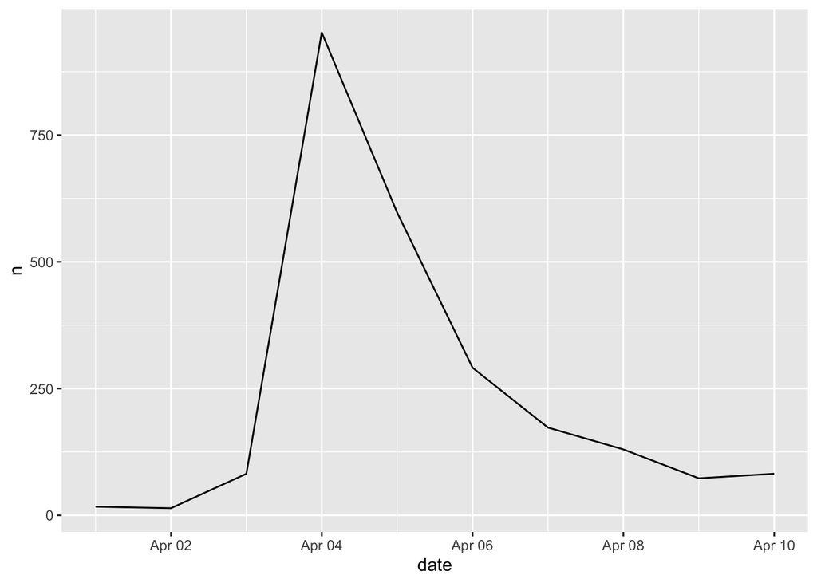

```r
#simple plot of tweets per day
tweets %>%
  count(date) %>%
  ggplot(aes(x = date, y = n))+
  geom_line()
```

```r
#let's clean up the URLs from the tweets
tweets$text <- gsub("http[^[:space:]]*", "",tweets$text)
tweets$text <- str_to_lower(tweets$text)
tweets$text <- iconv(tweets$text, "latin1", "ASCII", sub="")

#load sentiment lexicons
bing_sent <- get_sentiments('bing')
nrc_sent <- get_sentiments('nrc')

#tokenize tweets to individual words
words <- tweets %>%
  select(id, date, text) %>%
  unnest_tokens(output = word, input = text, token = "words") %>%
  anti_join(stop_words, by = "word") %>%
  left_join(bing_sent, by = "word") %>%
  left_join(
    tribble(
      ~sentiment, ~sent_score,
      "positive", 1,
      "negative", -1),
    by = "sentiment")
```

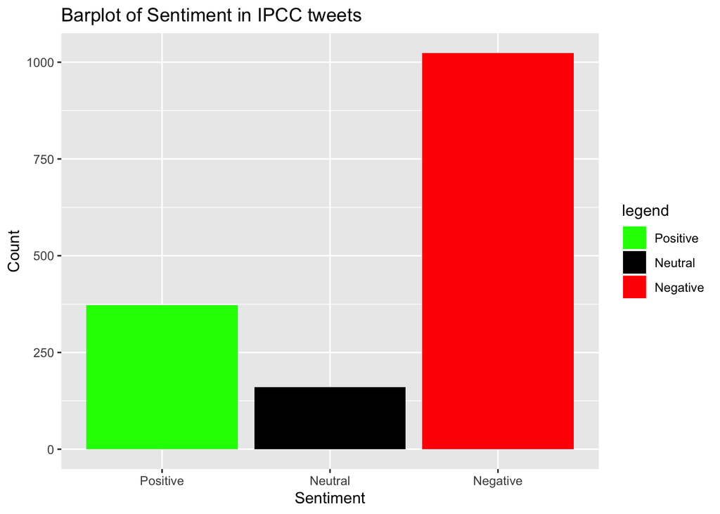

```r
#take average sentiment score by tweet
tweets_sent <- tweets %>%
  left_join(
    words %>%
      group_by(id) %>%
      summarize(
        sent_score = mean(sent_score, na.rm = T)),
    by = "id")

neutral <- length(which(tweets_sent$sent_score == 0))
positive <- length(which(tweets_sent$sent_score > 0))
negative <- length(which(tweets_sent$sent_score < 0))

Sentiment <- c("Positive","Neutral","Negative")
Count <- c(positive,neutral,negative)
output <- data.frame(Sentiment,Count)
output$Sentiment<-factor(output$Sentiment,levels=Sentiment)
ggplot(output, aes(x=Sentiment,y=Count))+
  geom_bar(stat = "identity", aes(fill = Sentiment))+
  scale_fill_manual("legend", values = c("Positive" = "green", "Neutral" = "black", "Negative" = "red"))+
  ggtitle("Barplot of Sentiment in IPCC tweets")
```

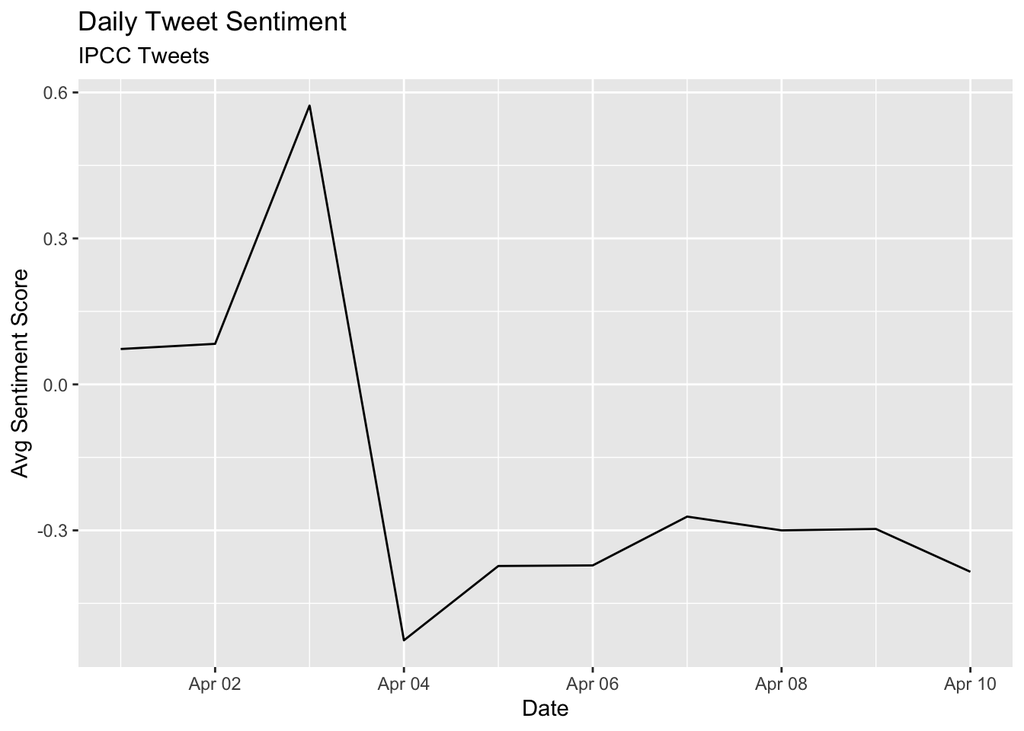

```r
# tally sentiment score per day
daily_sent <- tweets_sent %>%
  group_by(date) %>%
  summarize(sent_score = mean(sent_score, na.rm = T))

daily_sent %>%
  ggplot( aes(x = date, y = sent_score)) +
  geom_line() +
    labs(x = "Date",
    y = "Avg Sentiment Score",
    title = "Daily Tweet Sentiment",
    subtitle = "IPCC Tweets")
```

Now let’s try a new type of text visualization: the wordcloud.

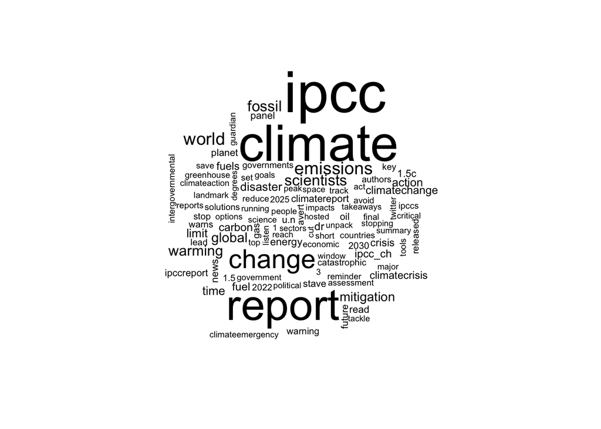

```r
words %>%
   anti_join(stop_words) %>%
   count(word) %>%
   with(wordcloud(word, n, max.words = 100))
```

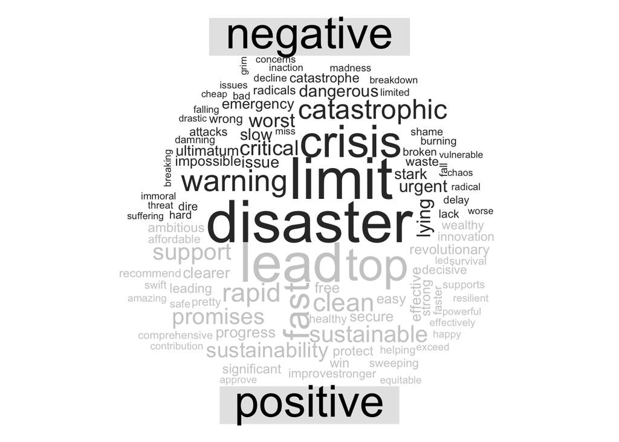

```r
words %>%
inner_join(get_sentiments("bing")) %>%
count(word, sentiment, sort = TRUE) %>%
acast(word ~ sentiment, value.var = "n", fill = 0) %>%
comparison.cloud(colors = c("gray20", "gray80"),
                   max.words = 100)
```

#### The quanteda package

quanteda is a package (actually a family of packages) full of tools for conducting text analysis. quanteda.sentiment (not yet on CRAN, download from github) is the quanteda modular package for conducting sentiment analysis.

quanteda has its own built in functions for cleaning text data. Let’s take a look at some. First we have to clean the messy tweet data:

```r
corpus <- corpus(dat$Title) #enter quanteda
summary(corpus)
```

|  | Text | Types | Tokens | Sentences |
| --- | --- | --- | --- | --- |
| 1 | text1 | 43 | 53 | 2 |
| 2 | text2 | 37 | 42 | 2 |
| 3 | text3 | 31 | 32 | 2 |
| 4 | text4 | 42 | 49 | 3 |
| 5 | text5 | 21 | 25 | 2 |
| 6 | text6 | 30 | 33 | 1 |
| 7 | text7 | 10 | 12 | 1 |
| 8 | text8 | 40 | 42 | 2 |
| 9 | text9 | 16 | 17 | 1 |
| 10 | text10 | 36 | 42 | 2 |

[output cut: 90 more lines]

```r
tokens <- tokens(corpus) #tokenize the text so each doc (page, in this case) is a list of tokens (words)

#examine the uncleaned version
tokens
```

```
## Tokens consisting of 2,411 documents.
## text1 :
##  [1] "thank"       "you"         ","           "followers"   ","
##  [6] "for"         "the"         "great"       "photo"       "suggestions"
## [11] "for"         "our"
## [ ... and 41 more ]
##
## text2 :
##  [1] "Greenpeace" ":"          "The"        "real"       "solution"
##  [6] "to"         "the"        "climate"    "crisis"     "will"
## [11] "require"    "a"
## [ ... and 30 more ]
##
## text3 :
##  [1] "Governments"    "have"           "a"              "responsibility"
##  [5] "to"             "ensure"         "that"           "#IPCCReport"
##  [9] "is"             "grounded"       "in"             "rapid"
## [ ... and 20 more ]
##
## text4 :
##  [1] "Next"      "week"      ","         "the"       "IPCC"      "will"
##  [7] "publish"   "a"         "new"       "report"    "detailing" "their"
## [ ... and 37 more ]
##
## text5 :
##  [1] "Live"       "stream"     "of"         "virtual"    "IPCC"
##  [6] "press"      "conference" "releasing"  "the"        "report"
## [11] "on"         "mitigation"
## [ ... and 13 more ]
##
## text6 :
##  [1] "Attention"   "journalists" ":"           "The"         "deadline"
##  [6] "for"         "embargoed"   "materials"   "for"         "the"
## [11] "upcoming"    "@IPCC_CH"
## [ ... and 21 more ]
##
## [ reached max_ndoc ... 2,405 more documents ]
```

```r
#clean it up
tokens <- tokens(tokens, remove_punct = TRUE,
                      remove_numbers = TRUE)

tokens <- tokens_select(tokens, stopwords('english'),selection='remove') #stopwords lexicon built in to quanteda

#tokens <- tokens_wordstem(tokens) #stem words down to their base form for comparisons across tense and quantity

tokens <- tokens_tolower(tokens)
```

We can use the kwic function (keywords-in-context) to briefly examine the context in which certain words or patterns appear.

```r
head(kwic(tokens, pattern = "climate", window = 3))
```

|  | docname | from | to | pre | keyword | post | pattern |
| --- | --- | --- | --- | --- | --- | --- | --- |
| 1 | text2 | 4 | 4 | greenpeace real solution | climate | crisis require rapid | climate |
| 2 | text2 | 17 | 17 | upcoming #ipcc report | climate | solutions set publication | climate |
| 3 | text5 | 10 | 10 | releasing report mitigation | climate | change a.m gmt | climate |
| 4 | text6 | 9 | 9 | upcoming @ipcc_ch report | climate | mitigation extended today | climate |
| 5 | text7 | 4 | 4 | ipcc report physics | climate | change https://t.co/xnxp3fup2a | climate |
| 6 | text10 | 10 | 10 | much lose critical | climate | water risks grow | climate |

```r
head(kwic(tokens, pattern = phrase("climate change"), window = 3))
```

|  | docname | from | to | pre | keyword | post | pattern |
| --- | --- | --- | --- | --- | --- | --- | --- |
| 1 | text5 | 10 | 11 | releasing report mitigation | climate change | a.m gmt o | climate change |
| 2 | text7 | 4 | 5 | ipcc report physics | climate change | https://t.co/xnxp3fup2a | climate change |
| 3 | text14 | 15 | 16 | avert worst effects | climate change | anyone think revolution | climate change |
| 4 | text15 | 10 | 11 | s #climatereport emissions | climate change | meenakshi raman @sahabatalammsia | climate change |
| 5 | text20 | 1 | 2 |  | climate change | want learn 100s | climate change |
| 6 | text24 | 6 | 7 | report revealed threat | climate change | team weighed findings | climate change |

```r
hash_tweets <- tokens(corpus, remove_punct = TRUE) %>%
               tokens_keep(pattern = "#*")

dfm_hash<- dfm(hash_tweets)

tstat_freq <- textstat_frequency(dfm_hash, n = 100)
head(tstat_freq, 10)
```

|  | feature | frequency | rank | docfreq | group |
| --- | --- | --- | --- | --- | --- |
| 1 | #ipcc | 464 | 1 | 460 | all |
| 2 | #climatechange | 137 | 2 | 135 | all |
| 3 | #climatecrisis | 118 | 3 | 117 | all |
| 4 | #climatereport | 97 | 4 | 97 | all |
| 5 | #ipccreport | 87 | 5 | 87 | all |
| 6 | #climate | 68 | 6 | 67 | all |
| 7 | #climateemergency | 45 | 7 | 45 | all |
| 8 | #climateaction | 44 | 8 | 44 | all |
| 9 | #globalwarming | 24 | 9 | 24 | all |
| 10 | #climateactionnow | 23 | 10 | 23 | all |

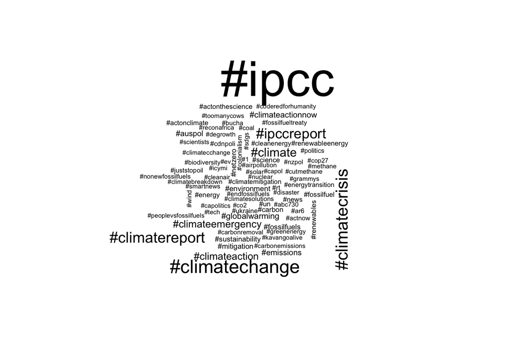

```r
#tidytext gives us tools to convert to tidy from non-tidy formats
hash_tib<- tidy(dfm_hash)

hash_tib %>%
   count(term) %>%
   with(wordcloud(term, n, max.words = 100))
```

Create the sparse matrix representation known as the document-feature matrix. quanteda’s textstat_polarity function has multiple ways to combine polarity to a single score. The sent_logit value to fun argument is the log of (pos/neg) counts.

```r
dfm <- dfm(tokens)

topfeatures(dfm, 12)
```

```
##    climate       ipcc     report     change        now      #ipcc      world
##       1396       1243       1225        651        505        464        346
##  emissions      never        new     latest scientists
##        333        291        279        279        274
```

```r
dfm.sentiment <- dfm_lookup(dfm, dictionary = data_dictionary_LSD2015)

head(textstat_polarity(tokens, data_dictionary_LSD2015, fun = sent_logit))
```

|  | doc_id | sentiment |
| --- | --- | --- |
| 1 | text1 | 2.197225 |
| 2 | text2 | -1.098612 |
| 3 | text3 | 1.945910 |
| 4 | text4 | 0.000000 |
| 5 | text5 | 1.098612 |
| 6 | text6 | 1.098612 |

### Assignment

You will use the tweet data from class today for each part of the following assignment.

1. Think about how to further clean a twitter data set. Let’s assume that the mentions of twitter accounts is not useful to us. Remove them from the text field of the tweets tibble.

```r
tweets$text <- str_remove(tweets$text, "@.*")
```

2. Compare the ten most common terms in the tweets per day. Do you notice anything interesting?

```r
#tokenize tweets to individual words
words <- tweets %>%
  select(id, date, text) %>%
  unnest_tokens(output = word, input = text, token = "words") %>%
  anti_join(stop_words, by = "word") %>%
  left_join(bing_sent, by = "word") %>%
  left_join(
    tribble(
      ~sentiment, ~sent_score,
      "positive", 1,
      "negative", -1),
    by = "sentiment")

words %>%
  group_by(word) %>%
  summarize(n = n()) %>%
  arrange(desc(n))
```

| word | n |
| --- | --- |
| ipcc | 1577 |
| climate | 1378 |
| report | 1084 |
| change | 621 |
| world | 332 |
| emissions | 326 |
| scientists | 269 |
| fossil | 255 |
| warming | 233 |
| global | 199 |

[output cut: 5251 more lines]

All 10 words are related directly to the IPCC report or climate change. “ipcc” is mentioned most, followed by “climate” and “report”. None of this is particularly surprising to me.

3. Adjust the wordcloud in the “wordcloud” chunk by coloring the positive and negative words so they are identifiable.

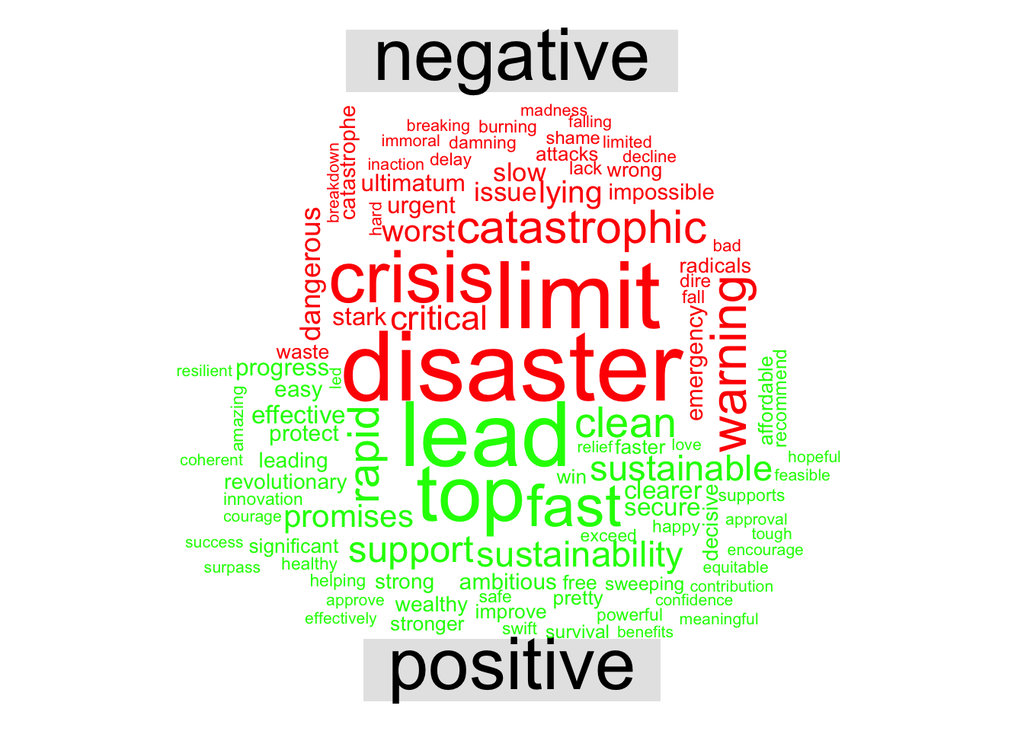

```r
words %>%
  anti_join(stop_words) %>%
  inner_join(get_sentiments("bing")) %>%
  count(word, sentiment, sort = TRUE) %>%
  acast(word ~ sentiment, value.var = "n", fill = 0) %>%
  comparison.cloud(colors = c("red", "green"),
                   max.words = 100)
```

4. Let’s say we are interested in the most prominent entities in the Twitter discussion. Which are the top 10 most tagged accounts in the data set. Hint: the “explore_hashtags” chunk is a good starting point.

```r
hash_tweets <- tokens(corpus, remove_punct = TRUE) %>%
               tokens_keep(pattern = "@*")

dfm_hash<- dfm(hash_tweets)

tstat_freq <- textstat_frequency(dfm_hash, n = 100)
head(tstat_freq, 10)
```

|  | feature | frequency | rank | docfreq | group |
| --- | --- | --- | --- | --- | --- |
| 1 | @ipcc_ch | 131 | 1 | 131 | all |
| 2 | @logicalindians | 38 | 2 | 38 | all |
| 3 | @antonioguterres | 16 | 3 | 16 | all |
| 4 | @nytimes | 14 | 4 | 14 | all |
| 5 | @yahoo | 14 | 4 | 14 | all |
| 6 | @potus | 13 | 6 | 13 | all |
| 7 | @un | 12 | 7 | 12 | all |
| 8 | @youtube | 11 | 8 | 11 | all |
| 9 | @conversationedu | 10 | 9 | 10 | all |
| 10 | @ipcc | 9 | 10 | 9 | all |

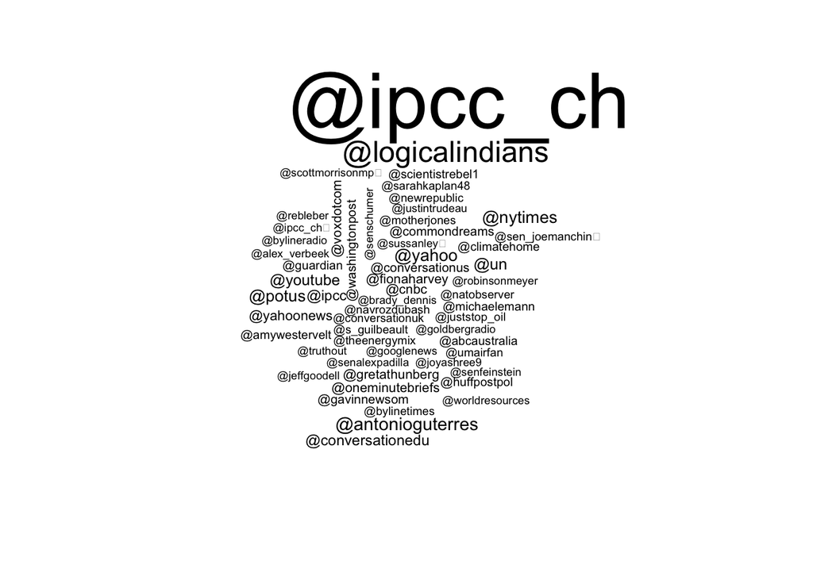

```r
#tidytext gives us tools to convert to tidy from non-tidy formats
hash_tib<- tidy(dfm_hash)

hash_tib %>%
   count(term) %>%
   with(wordcloud(term, n, max.words = 100))
```

5. The Twitter data download comes with a variable called “Sentiment” that must be calculated by Brandwatch. Use your own method to assign each tweet a polarity score (Positive, Negative, Neutral) and compare your classification to Brandwatch’s (hint: you’ll need to revisit the “raw_tweets” data frame).

```r
dat<- raw_tweets[,c(4,6, 10)] # Extract Date and Title fields

tweets <- tibble(text = dat$Title,
                  id = seq(1:length(dat$Title)),
                 date = as.Date(dat$Date,'%m/%d/%y'),
                 sentiment_brandwatch = dat$Sentiment)

#let's clean up the URLs from the tweets
tweets$text <- gsub("http[^[:space:]]*", "",tweets$text)
tweets$text <- iconv(tweets$text, "latin1", "ASCII", sub="")
tweets$text <- str_to_lower(tweets$text)

#load sentiment lexicons
bing_sent <- get_sentiments('bing')
nrc_sent <- get_sentiments('nrc')

#tokenize tweets to individual words
words <- tweets %>%
  select(id, date, text, sentiment_brandwatch) %>%
  unnest_tokens(output = word, input = text, token = "words") %>%
  anti_join(stop_words, by = "word") %>%
  left_join(bing_sent, by = "word") %>%
  left_join(
    tribble(
      ~sentiment, ~sent_score,
      "positive", 1,
      "negative", -1),
    by = "sentiment")

compare_sents <- words %>%
  mutate(sent_score = replace_na(sent_score, 0)) %>%
  group_by(id) %>%
  summarize(sentiment = mean(sent_score),
            sentiment_brandwatch = first(sentiment_brandwatch)) %>%
  mutate(sentiment = case_when(sentiment >= 0.2 ~ "positive",
    sentiment < 0.2 & sentiment > -0.2 ~ "neutral",
    sentiment <= -0.2 ~ "negative"))

table(compare_sents$sentiment, compare_sents$sentiment_brandwatch)
```

```
##
##            negative neutral positive
##   negative       70     112        0
##   neutral       180    2009       18
##   positive        0      15        1
```